# Week 17 - Lab model script

Amy Atkinson

16/02/2022

# Lecture 7 (Non-parametric tests: Kruskal-Wallis test and Friedman’s ANOVA)

## Lecture

This lecture comprises two parts:

**Part 1: Assessing normality with three or more independent groups and the Kruskal-Wallis test**

Part 1 covers how to assess the assumption of normality with three or more independent groups. It also covers the theory behind the Kruskal-Wallis test, how to calculate the Kruskal-Wallis test statistic manually, how to run the test in R, how to interpret the output, and how to conduct post-hoc comparisons.

Lecture recording:

Slides:

**Part 2: Assessing normality with three or more repeated measures and Friedman’s ANOVA**

Part 2 covers how to assess the assumption of normality with three or more repeated measures. It also covers Friedman’s ANOVA, including: the theory behind the test, how to calculate the test statistic manually, how to run the test in R and how to interpret output, and how to conduct post-hoc comparisons.

Lecture recording:

Slides:

## Lab preparation

Before the lab, please watch the following video. This walks you through how to perform Friedman’s ANOVA in R.

Please also take a look at this R markdown file. This covers how to run a Kruskal-Wallis test and Friedman’s ANOVA in R:

## Lab

In the lab, we’ll practice running a Kruskal-Wallis test and Friedman’s ANOVA in R. Please download the following zip file which contains two datasets: “course_data_set.csv” and “memory_data.csv”.

The datasets relate to the following research questions:

**1. Course dataset**

You are a psychology lecturer. You hear that the library is offering three statistics courses. You are interested in whether students who attend the courses perform significantly differently from each other.

You recruit 18 people and assign each one to a course. After the courses are finished, you ask them to write an R script. You time how long it takes students to complete the task. You are interested in whether there is a significant effect of course on the time taken to complete the task.

**2. Memory dataset**

You are a developmental psychologist. You are interested in whether working memory develops between 15 and 17 years of age.

You recruit a sample of adolescents and test them on a working memory task when they are 15 years of age, 16 years of age, and 17 years of age.

You then examine whether there is a significant effect of age on working memory score.

## Lab - model script

Here is a model script that produces the answers to the above research questions. I use the word ‘model’ loosely, as you may have used different functions you’ve learned over the last two years (and that’s absolutely fine!). So don’t worry if you haven’t used the exact same functions as me. You should end up with the same results and interpretation at the end though.

### Course data:

```r
library(tidyverse)
library(cowplot)
library(FSA)
library(PMCMRplus)
```

#### Read in the data

This chunk reads in the data.

```r
course_data <- read.csv("course_data_set.csv")
```

#### Check whether the data meets the assumption of normality

Remember, we need to check if the assumption of normality is met for each group separately.

##### Course 1

###### Filter data:

This produces a new dataset containing data for the Course 1 group only:

```r
course_1 <- course_data %>% filter(Group == "Course 1")
```

###### Produce a Q-Q plot:

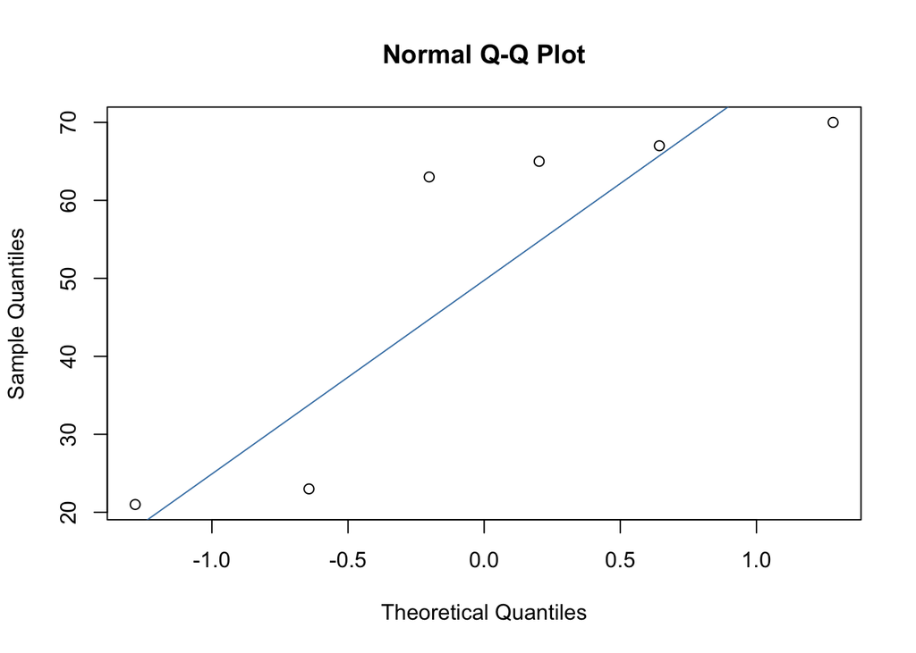

```r
qqnorm(course_1$Time)
qqline(course_1$Time, col = "steelblue")
```

Quite a few of the datapoints deviate from the line, suggesting data from this group might violates the assumption of normality.

###### Shapiro-Wilk test:

```r
shapiro.test(course_1$Time)
```

```
##
##  Shapiro-Wilk normality test
##
## data:  course_1$Time
## W = 0.73459, p-value = 0.01402
```

This suggests that the data in the course 1 group violates the assumption of normality.

##### Course 2:

###### Filter data:

This produces a new dataset containing data for the Course 2 group only:

```r
course_2 <- course_data %>% filter(Group == "Course 2")
```

###### Produce a Q-Q plot:

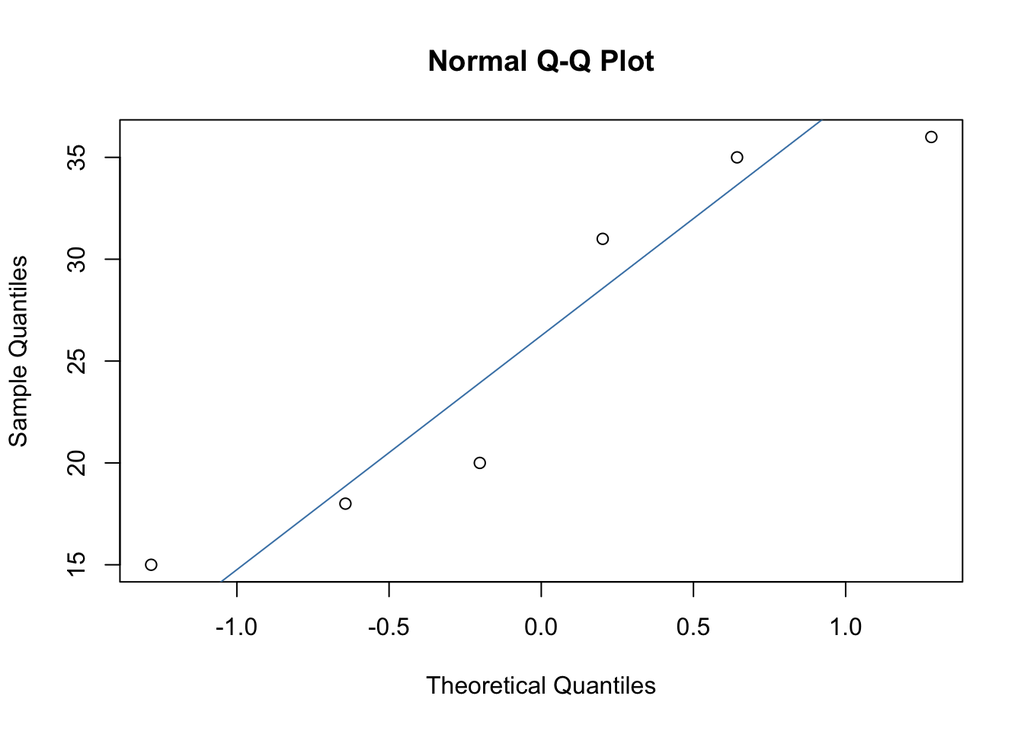

```r
qqnorm(course_2$Time)
qqline(course_2$Time, col = "steelblue")
```

The points do generally follow the line, although there is some slight deviation.

###### Shapiro-Wilk test:

```r
shapiro.test(course_2$Time)
```

```
##
##  Shapiro-Wilk normality test
##
## data:  course_2$Time
## W = 0.86774, p-value = 0.2173
```

The Shapiro-Wilk test is not significant, suggesting the data does not violate the assumption of normality.

##### Course 3:

###### Filter data:

This produces a new dataset containing data for the Course 3 group only:

```r
course_3 <- course_data %>% filter(Group == "Course 3")
```

###### Produce a Q-Q plot:

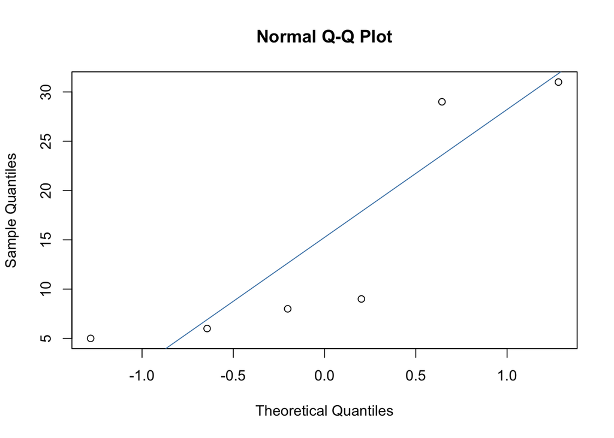

```r
qqnorm(course_3$Time)
qqline(course_3$Time, col = "steelblue")
```

Quite a few of the points deviate from the line.

###### Shapiro-Wilk test:

```r
shapiro.test(course_3$Time)
```

```
##
##  Shapiro-Wilk normality test
##
## data:  course_3$Time
## W = 0.75434, p-value = 0.02196
```

The Shapiro-Wilk test suggests that data in this group violates the assumption of normality.

###### Interpretation:

Data from the Course 1 and Course 3 groups appears to violates the assumption of normality. Data from the Course 2 group does not appear to violate the assumption. We might therefore decide to run the Kruskal-Wallis test.

#### Exploring our dataset:

First, let’s explore the data.

##### Descriptive statistics:

Medians, range, and number of participants per group:

```r
course_data %>%
  group_by(Group) %>% # plots data per group
  summarise(med = median(Time), # median
            min = min(Time), # lowest value
            max = max(Time), # highest value
            n = n()) # number of participants per group
```

```
## # A tibble: 3 × 5
##   Group      med   min   max     n
##   <chr>    <dbl> <int> <int> <int>
## 1 Course 1  64      21    70     6
## 2 Course 2  25.5    15    36     6
## 3 Course 3   8.5     5    31     6
```

Plot:

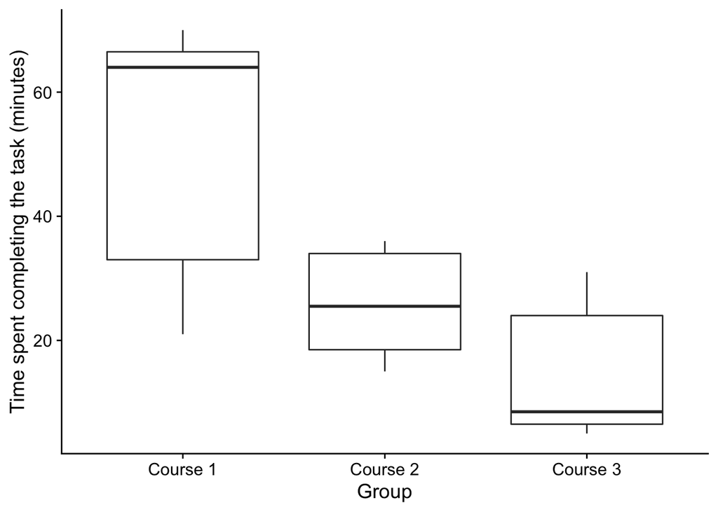

```r
ggplot(course_data, aes(x=Group, y=Time)) +
  geom_boxplot() +
  labs(y = "Time spent completing the task (minutes)") +
  theme_cowplot()
```

The median for the Course 3 group is lowest, Course 2 is intermediate, and Course 1 is highest. There are 6 participants in each group

#### Performing the Kruskal-Wallis test:

```r
model1 <- kruskal.test(Time ~ Group, data = course_data)
model1
```

```
##
##  Kruskal-Wallis rank sum test
##
## data:  Time by Group
## Kruskal-Wallis chi-squared = 7.7653, df = 2, p-value = 0.0206
```

From this, we can see that there is a significant difference between the groups.

#### Post-hoc tests:

Post-hoc tests were therefore conducted to understand which groups significantly differ from each other.

```r
dunnTest(Time~Group,data=course_data, method = "holm")
```

```
## Dunn (1964) Kruskal-Wallis multiple comparison
```

```
##   p-values adjusted with the Holm method.
```

```
##            Comparison        Z     P.unadj      P.adj
## 1 Course 1 - Course 2 1.433696 0.151659075 0.30331815
## 2 Course 1 - Course 3 2.786239 0.005332352 0.01599706
## 3 Course 2 - Course 3 1.352543 0.176201589 0.17620159
```

Here, we can see that the difference between Course 1 and Course 3 is significant.

#### Interpretation:

There was a significant effect of course on the amount of time required to complete the task, *H*(2) = 7.77, *p* = .020. Post-hoc comparisons were conducted using Dunn’s test. P-values were corrected using Bonferroni-Holm. There was a significant difference between Course 1 (median = 64, range = 21-70) and Course 3 (median = 8.50, range = 5-31; *p* = .016), with students who completed Course 3 completing the task faster. No significant difference emerged between Course 1 and Course 2 (median = 25.5, range = 15-36; *p* = 0.303), or Course 2 and Course 3 (*p* = .176).

### Memory data:

#### Read in the data

This chunk reads in the data.

```r
memory_data <- read.csv("memory_data.csv")
```

#### Check whether the data meets the assumption of normality

##### Timepoint 1 (Age 15):

###### Produce a Q-Q plot:

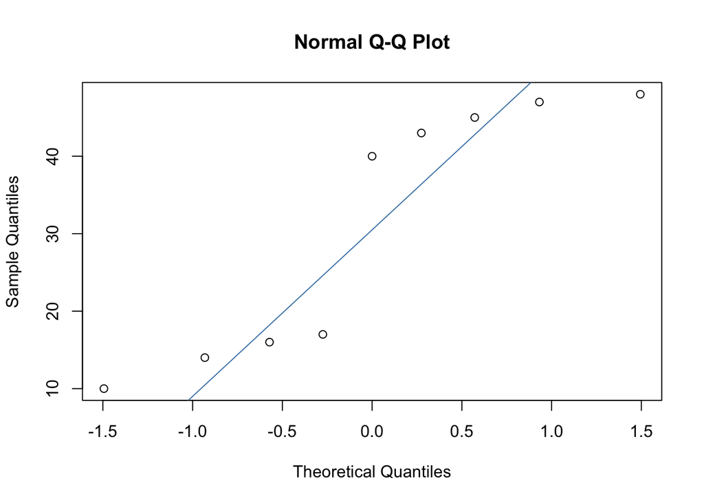

```r
qqnorm(memory_data$Age_15)
qqline(memory_data$Age_15, col = "steelblue")
```

Some of the points deviate quite a lot from the line. This suggests the assumption of normality may be violated.

###### Shapiro-Wilk test:

```r
shapiro.test(memory_data$Age_15)
```

```
##
##  Shapiro-Wilk normality test
##
## data:  memory_data$Age_15
## W = 0.80537, p-value = 0.02351
```

The Shapiro-Wilk test is significant, suggesting the assumption of normality is violated.

##### Timepoint 2 (Age 16):

###### Produce a Q-Q plot:

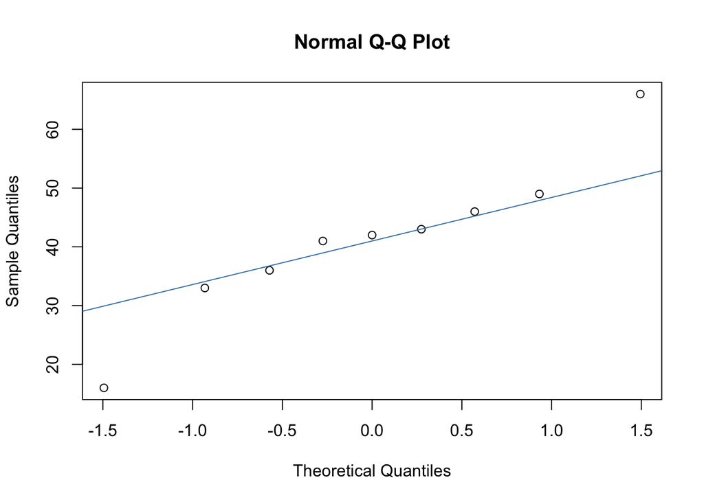

```r
qqnorm(memory_data$Age_16)
qqline(memory_data$Age_16, col = "steelblue")
```

The points generally follow the line well.

###### Shapiro-Wilk test:

```r
shapiro.test(memory_data$Age_16)
```

```
##
##  Shapiro-Wilk normality test
##
## data:  memory_data$Age_16
## W = 0.94537, p-value = 0.6394
```

The Shapiro-Wilk test is non-significant and most of the points follow the line, suggesting the assumption of normality is not violated.

##### Timepoint 3 (Age 17):

###### Produce a Q-Q plot:

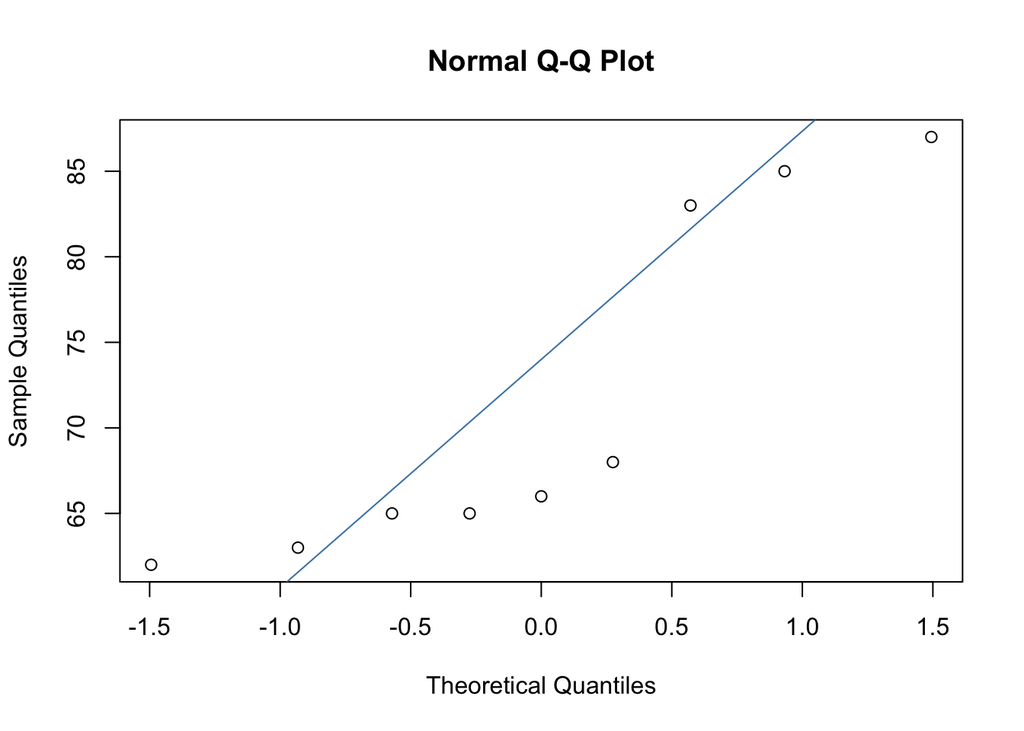

```r
qqnorm(memory_data$Age_17)
qqline(memory_data$Age_17, col = "steelblue")
```

The points deviate from the line quite a bit.

###### Shapiro-Wilk test:

```r
shapiro.test(memory_data$Age_17)
```

```
##
##  Shapiro-Wilk normality test
##
## data:  memory_data$Age_17
## W = 0.78255, p-value = 0.01289
```

The Shapiro-Wilk test is significant, suggesting the assumption of normality may have been violated.

###### Interpretation:

Data from the Age_15 and Age_17 timepoints appears to violate the assumption. A Friedman’s ANOVA will therefore be run.

#### Exploring the data:

##### Examining the descriptive statistics:

Median, minimum, maximum per condition:

```r
memory_data %>%
  summarise(med_Age_15 = median(Age_15), med_Age_16 = median(Age_16), med_Age_17 = median(Age_17),
            min_Age_15 = min(Age_15), min_Age_16 = min(Age_16), min_Age_17 = min(Age_17),
            max_Age_15 = max(Age_15), max_Age_16 = max(Age_16), max_Age_17 = max(Age_17),
            n = n()) # n only need to be calculated once since each participant contributes data to all three conditions
```

```
##   med_Age_15 med_Age_16 med_Age_17 min_Age_15 min_Age_16 min_Age_17 max_Age_15
## 1         40         42         66         10         16         62         48
##   max_Age_16 max_Age_17 n
## 1         66         87 9
```

##### Data visualisation:

```r
memory_data_long <- gather(memory_data, Age_group, Score, Age_15:Age_17) # coverts the data to long format
memory_data_long
```

```
##    Participant Age_group Score
## 1            1    Age_15    45
## 2            2    Age_15    40
## 3            3    Age_15    43
## 4            4    Age_15    14
## 5            5    Age_15    16
## 6            6    Age_15    47
## 7            7    Age_15    17
## 8            8    Age_15    48
## 9            9    Age_15    10
## 10           1    Age_16    66
## 11           2    Age_16    41
## 12           3    Age_16    42
## 13           4    Age_16    33
## 14           5    Age_16    46
## 15           6    Age_16    43
## 16           7    Age_16    16
## 17           8    Age_16    49
## 18           9    Age_16    36
## 19           1    Age_17    83
## 20           2    Age_17    66
## 21           3    Age_17    65
## 22           4    Age_17    65
## 23           5    Age_17    68
## 24           6    Age_17    87
## 25           7    Age_17    85
## 26           8    Age_17    62
## 27           9    Age_17    63
```

```r
memory_data_long$Age_group <- recode(memory_data_long$Age_group, "Age_15" = "15 years old",   # changes the factor level names
                                     "Age_16" = "16 year old",
                                     "Age_17" = "17 year old")
```

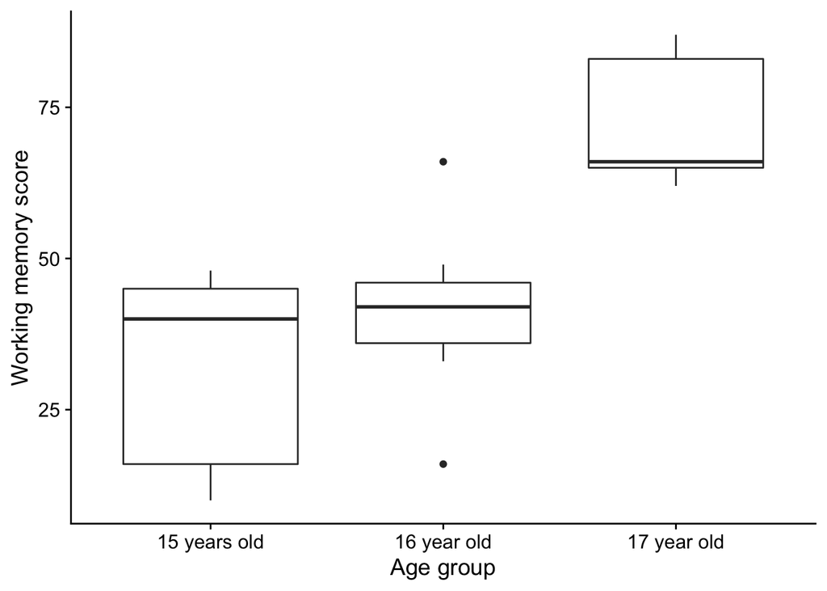

```r
ggplot(memory_data_long, aes(x=Age_group, y=Score)) +
  geom_boxplot() +
  labs(y = "Working memory score", x = "Age group") + # adds a y label which makes it clearer what our outcome measure is
  theme_cowplot() # formats the figure nicely
```

Here, we can see there is very little difference between the medians of the 15 and 16 year old groups. There is a large difference between the 15 and 17 year olds and the 16 and 17 year olds.

#### Performing the Friedman’s ANOVA

```r
# creates a new dataframe containing all columns except from the "Participant" column
memory_data_reduced <- memory_data %>% select(-Participant)
```

Run the model:

```r
model2 <- friedman.test(as.matrix(memory_data_reduced))
model2
```

```
##
##  Friedman rank sum test
##
## data:  as.matrix(memory_data_reduced)
## Friedman chi-squared = 14, df = 2, p-value = 0.0009119
```

The p-value is equal to 0.001 (if we round to three decimal places), indicating there is a significant effect of age group.

#### Post-hoc tests

```r
# requires PMCMRplus library
frdAllPairsConoverTest(memory_data_long$Score, memory_data_long$Age_group, memory_data_long$Participant, p.adjust = "holm")
```

```
##
##  Pairwise comparisons using Conover's all-pairs test for a two-way balanced complete block design
```

```
## data: y, groups and blocks
```

```
##             15 years old 16 year old
## 16 year old 0.4897       -
## 17 year old 0.0082       0.0242
```

```
##
## P value adjustment method: holm
```

The post-hoc tests revealed a significant difference between the Age_15 and Age_17 timepoints, and the Age_16 and Age_17 timepoints. There is no significant difference between the Age_15 and Age_16 timepoints.

#### Interpretation:

Friedman’s ANOVA revealed that there was a significant effect of age group on working memory score, $x^{2}_{F}$(2) = 14.00, *p* = .001. Post-hoc comparisons were then conducting using the Conover test. P-values were corrected using Bonferroni-Holm. There was a significant difference between performance at 15 year of age (median = 40; range = 10-48) and 17 years of age (median = 66; range = 62-87; *p* = 0.008), and 16 years of age (median = 42; range = 16-66) and 17 years of age (*p* = 0.024). Participants performed significantly better at the 17 year old timepoint relative to the 15 and 16 year old timepoint. No significant difference emerged between the 15 year old and 16 year old timepoints (*p* = 0.490).

## Worksheet:

The answers are in the next section.

### Activity 1: Understanding how the non-parametric tests differ and when to use them

In each of the following scenario, you are interested in whether the type of chocolate eaten affects feelings of contentment (response = 0-100). For each scenario, think about the following questions:

**Scenario 1: You recruit 20 participants. On day 1, they eat milk chocolate. On day 2, they eat dark chocolate. On day 3, they eat white chocolate.**

1. How would you check whether the assumption of normality is violated for this design?
2. If the assumption of normality is violated, which non-parametric test would you run?

**Scenario 2: You recruit 12 participants and randomly assign them to either a “white chocolate”, “milk chocolate”, or “dark chocolate” group.**

1. How would you check whether the assumption of normality is violated for this design?
2. If the assumption of normality is violated, which non-parametric test would you run?

**Scenario 3: You recruit 7 participants. On day 1, they eat milk chocolate and on day 2, they eat dark chocolate.**

1. How would you check whether the assumption of normality is violated for this design?
2. If the assumption of normality is violated, which non-parametric test would you run?

**Scenario 4: You recruit 10 participants and randomly assign them to either a “white chocolate” or “milk chocolate” group.**

1. How would you check whether the assumption of normality is violated for this design?
2. If the assumption of normality is violated, which non-parametric test would you run?

### Activity 2: Interpreting R output

Interpret the following R output. Part 1 uses an independent groups design, whilst part 2 uses a repeated measures design.

#### Part 1: An independent groups design

You are a developmental researcher interested in whether the books children are exposed to affects their language production (how many words they can say). You recruit 21 2-year-old children and assign them to one of three groups – “Pinocchio”, “Cinderella”, and “Gruffalo”. The children’s parents then read this story every day for three months (i.e. children in the “Gruffalo” group read the Gruffalo every day). You then ask their parents to complete a language production assessment on their child (score = 0-100).

##### Testing the assumption of normality:

###### Group 1:

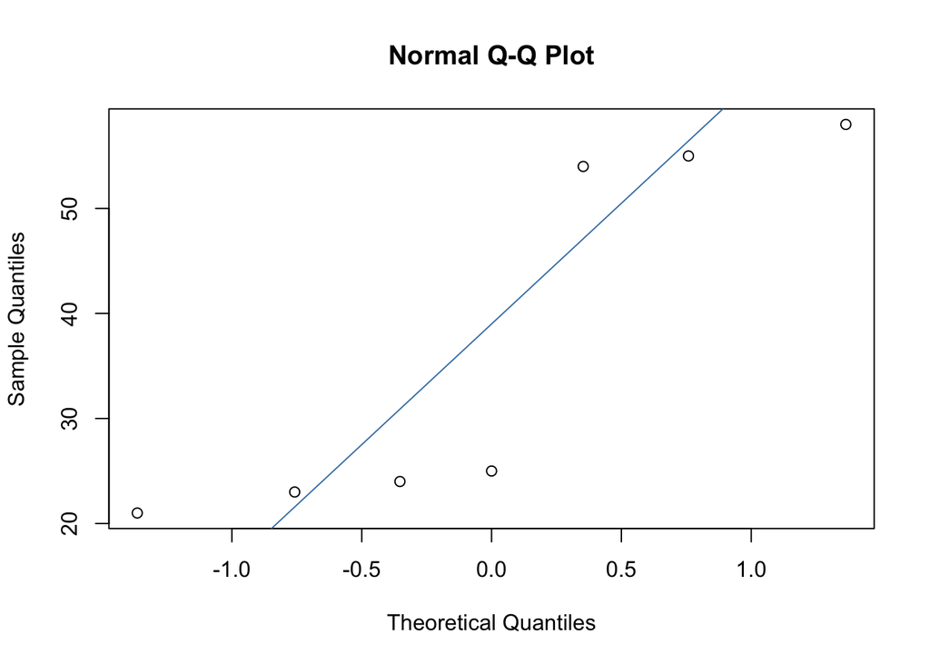

```
##
##  Shapiro-Wilk normality test
##
## data:  Pinocchio$Words
## W = 0.75208, p-value = 0.01334
```

###### Group 2:

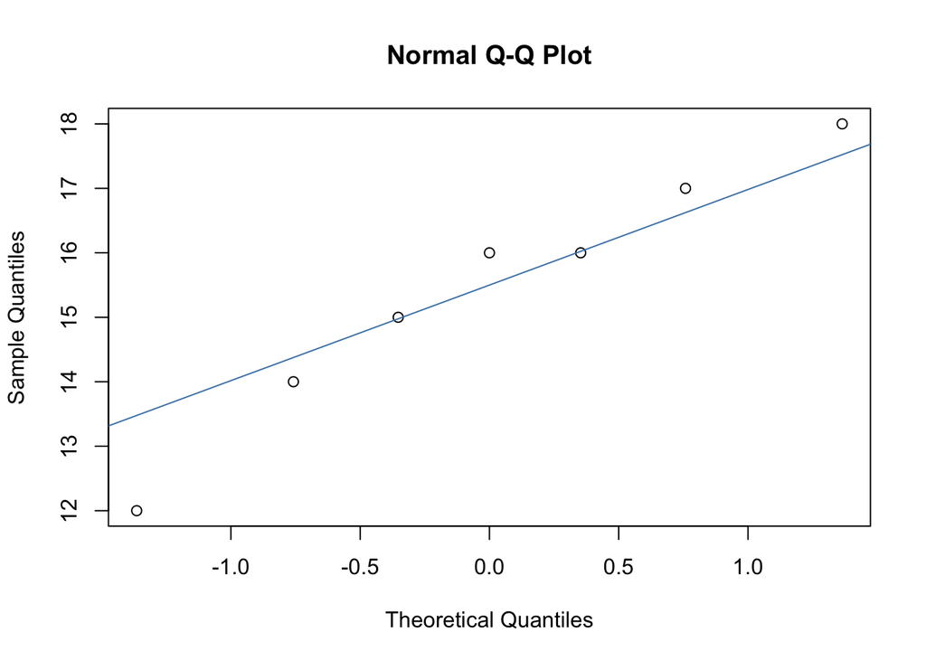

```
##
##  Shapiro-Wilk normality test
##
## data:  Cinderella$Words
## W = 0.96705, p-value = 0.8764
```

###### Group 3:

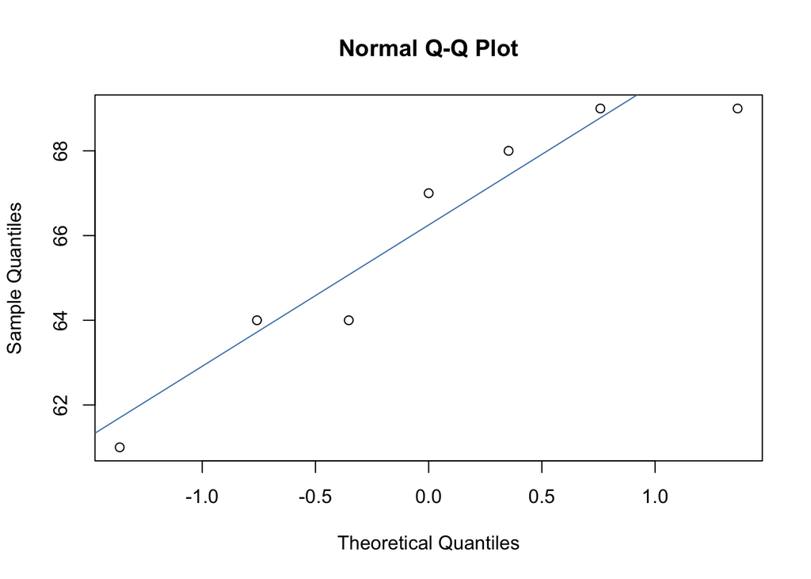

```
##
##  Shapiro-Wilk normality test
##
## data:  Gruffalo$Words
## W = 0.89119, p-value = 0.2809
```

Is the assumption violated?

##### Interpret the descriptive statistics and the model output

```
## # A tibble: 3 × 4
##   Book       med_words min_words max_words
##   <chr>          <int>     <int>     <int>
## 1 Cinderella        16        12        18
## 2 Gruffalo          67        61        69
## 3 Pinocchio         25        21        58
```

```
##
##  Kruskal-Wallis rank sum test
##
## data:  Words by Book
## Kruskal-Wallis chi-squared = 17.853, df = 2, p-value = 0.0001328
```

```
## Dunn (1964) Kruskal-Wallis multiple comparison
```

```
##   p-values adjusted with the Holm method.
```

```
##               Comparison         Z       P.unadj         P.adj
## 1  Cinderella - Gruffalo -4.225276 0.00002386477 0.00007159432
## 2 Cinderella - Pinocchio -2.112638 0.03463174827 0.06926349653
## 3   Gruffalo - Pinocchio  2.112638 0.03463174827 0.03463174827
```

What can we conclude? Report in APA format.

#### Part 2: A repeated measures design

You are a researcher interested in whether the number of hours sleep individuals get affects their performance on an attention task (score = 0-100). You recruit nine participants, with all participants taking part in three conditions. In the first condition, participants get 6 hours sleep the night before (6 hours). In the second condition, they get 8 hours sleep the night before (8 hours), and in the third condition, they get 10 hours sleep the night before (10 hours).

##### Testing the assumption of normality:

6 hours condition:

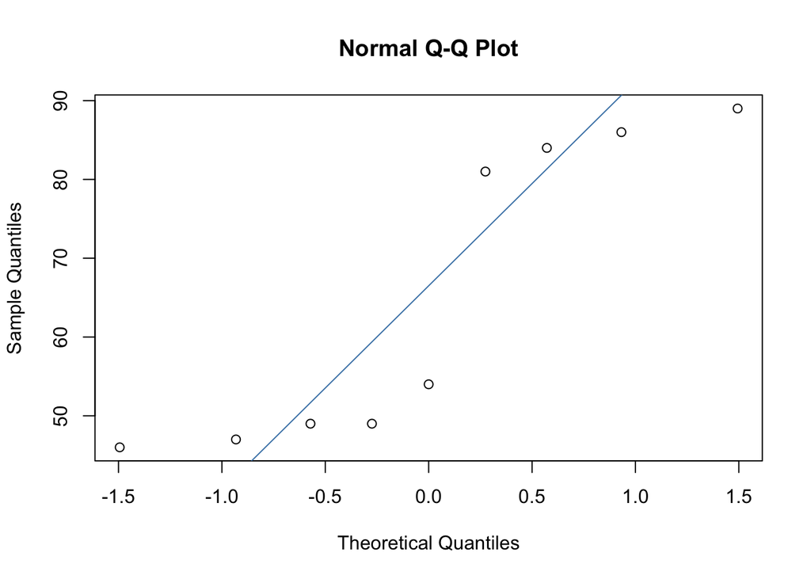

```
##
##  Shapiro-Wilk normality test
##
## data:  sleep_data$six_hours
## W = 0.7785, p-value = 0.01157
```

8 hours condition:

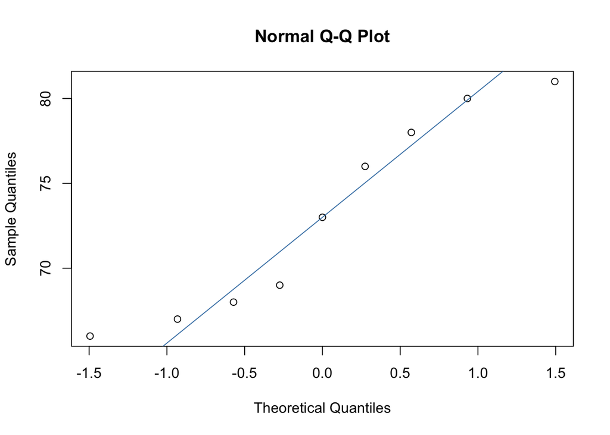

```
##
##  Shapiro-Wilk normality test
##
## data:  sleep_data$eight_hours
## W = 0.90246, p-value = 0.2666
```

10 hours condition:

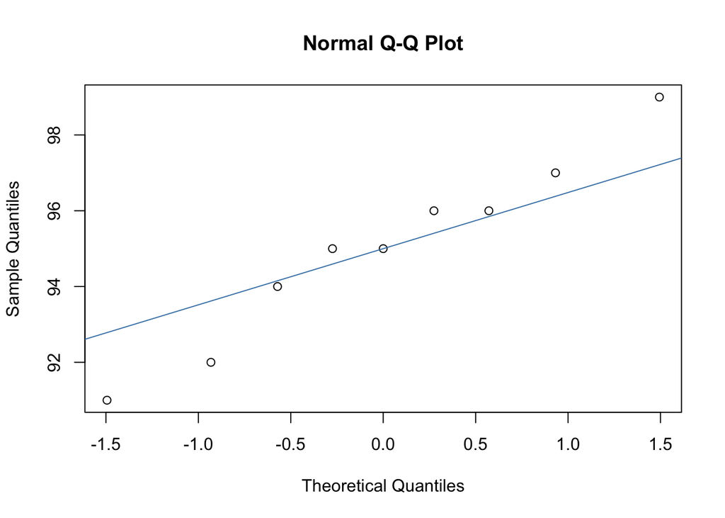

```
##
##  Shapiro-Wilk normality test
##
## data:  sleep_data$ten_hours
## W = 0.96963, p-value = 0.8915
```

Is the assumption violated?

##### Interpret the descriptive statistics and the model output

```
##    Participant   Condition Score
## 1            1   six_hours    46
## 2            2   six_hours    47
## 3            3   six_hours    49
## 4            4   six_hours    54
## 5            5   six_hours    89
## 6            6   six_hours    86
## 7            7   six_hours    84
## 8            8   six_hours    81
## 9            9   six_hours    49
## 10           1 eight_hours    66
## 11           2 eight_hours    68
## 12           3 eight_hours    69
## 13           4 eight_hours    73
## 14           5 eight_hours    76
## 15           6 eight_hours    78
## 16           7 eight_hours    67
## 17           8 eight_hours    80
## 18           9 eight_hours    81
## 19           1   ten_hours    96
## 20           2   ten_hours    97
## 21           3   ten_hours    95
## 22           4   ten_hours    96
## 23           5   ten_hours    94
## 24           6   ten_hours    92
## 25           7   ten_hours    91
## 26           8   ten_hours    95
## 27           9   ten_hours    99
```

```
##
##  Friedman rank sum test
##
## data:  as.matrix(sleep_data_reduced)
## Friedman chi-squared = 13.556, df = 2, p-value = 0.001139
```

```
##
##  Pairwise comparisons using Conover's all-pairs test for a two-way balanced complete block design
```

```
## data: y, groups and blocks
```

```
##           eight_hours six_hours
## six_hours 0.817       -
## ten_hours 0.015       0.014
```

```
##
## P value adjustment method: holm
```

```
##   med_six_hours med_eight_hours med_ten_hours min_six_hours min_eight_hours
## 1            54              73            95            46              66
##   min_ten_hours max_six_hours max_eight_hours max_ten_hours
## 1            91            89              81            99
```

What can we conclude? Report in APA format.

## Worksheet answers:

Answers are in purple below.

### Activity 1: Understanding how the non-parametric tests differ and when to use them

**Scenario 1: You recruit 20 participants. On day 1, they eat milk chocolate. On day 2, they eat dark chocolate. On day 3, they eat white chocolate.**

1. How would you check whether the assumption of normality is violated for this design?

Assess whether the assumption of normality is violated per condition. This can be done using Q-Q plots and the Shapiro-Wilk test

2. If the assumption of normality is violated, which non-parametric test would you run?

Friedman’s ANOVA

**Scenario 2: You recruit 12 participants and randomly assign them to either a “white chocolate”, “milk chocolate”, or “dark chocolate” group.**

1. How would you check whether the assumption of normality is violated for this design?

Assess whether the assumption of normality is violated per group. This can be done using Q-Q plots and the Shapiro-Wilk test.

2. If the assumption of normality is violated, which non-parametric test would you run?

Kruskal-Wallis test

**Scenario 3: You recruit 7 participants. On day 1, they eat milk chocolate and on day 2, they eat dark chocolate.**

1. How would you check whether the assumption of normality is violated for this design?

Calculate a difference score for each participant (Timepoint 1 – Timepoint 2). Assess whether the assumption of normality is violated for the “difference”. This can be done using Q-Q plots and the Shapiro-Wilk test.

2. If the assumption of normality is violated, which non-parametric test would you run?

Wilcoxon signed-rank test

**Scenario 4: You recruit 10 participants and randomly assign them to either a “white chocolate” or “milk chocolate” group.**

1. How would you check whether the assumption of normality is violated for this design?

Assess whether the assumption of normality is violated per group. This can be done using Q-Q plots and the Shapiro-Wilk test

2. If the assumption of normality is violated, which non-parametric test would you run?

Wilcoxon rank-sum test

### Activity 2: Interpreting R output

#### Part 1: An independent groups design

##### Testing the assumption of normality:

###### Group 1:

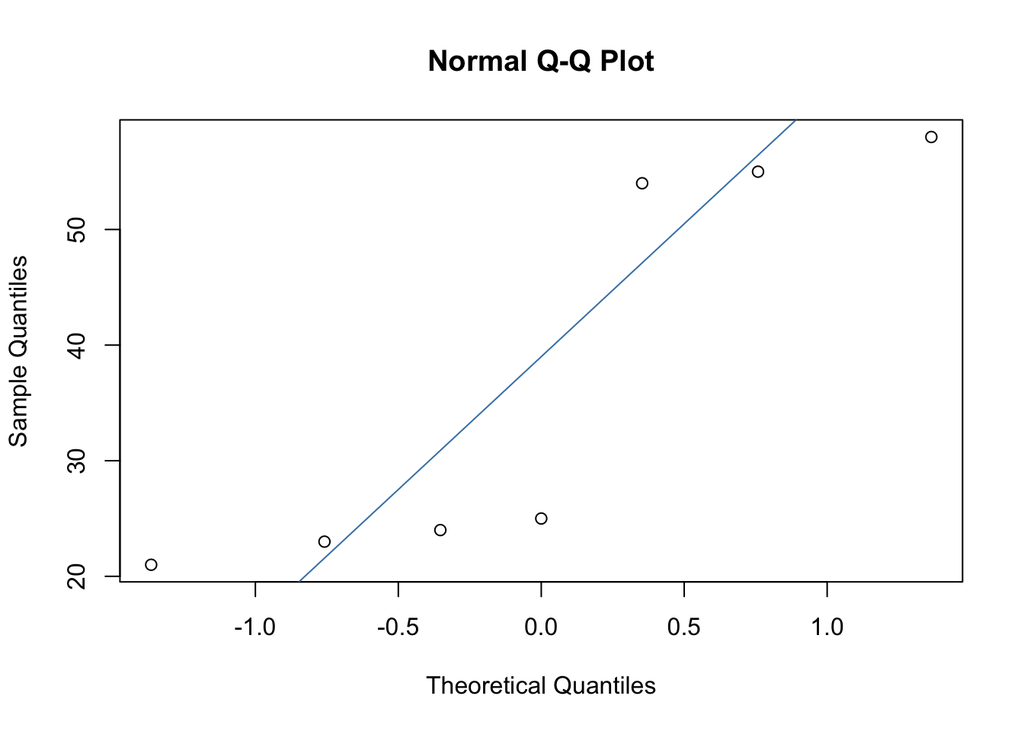

```
##
##  Shapiro-Wilk normality test
##
## data:  Pinocchio$Words
## W = 0.75208, p-value = 0.01334
```

###### Group 2:

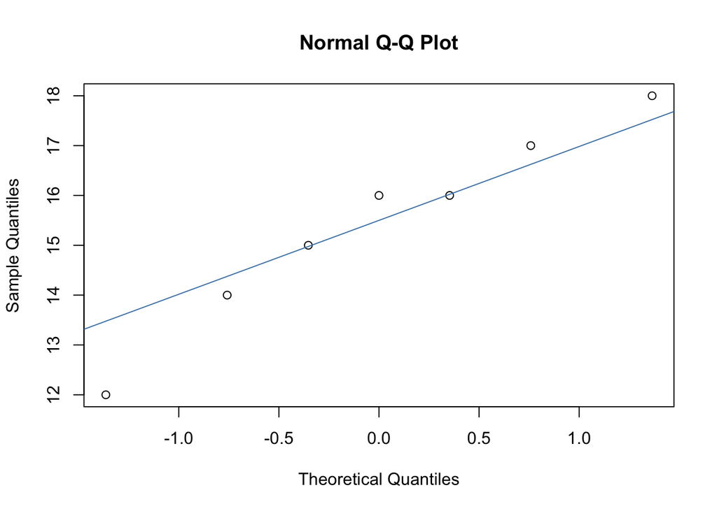

```
##
##  Shapiro-Wilk normality test
##
## data:  Cinderella$Words
## W = 0.96705, p-value = 0.8764
```

###### Group 3:

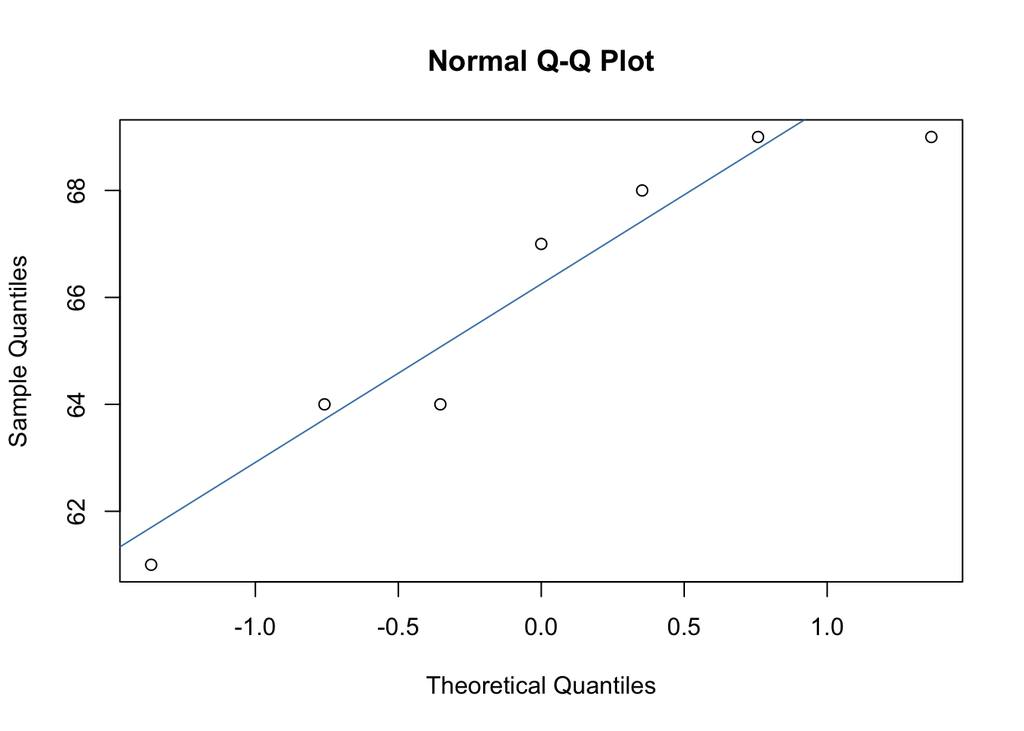

```
##
##  Shapiro-Wilk normality test
##
## data:  Gruffalo$Words
## W = 0.89119, p-value = 0.2809
```

**Is the assumption violated?**

The Q-Q plot and the Shapiro-Wilk test suggests that the assumption of normality is violated for the Pinocchio group. Data in the Cinderella and Gruffalo group does not appear to violate the assumption.

##### Interpret the descriptive statistics and the model output

```
## # A tibble: 3 × 4
##   Book       med_words min_words max_words
##   <chr>          <int>     <int>     <int>
## 1 Cinderella        16        12        18
## 2 Gruffalo          67        61        69
## 3 Pinocchio         25        21        58
```

```
##
##  Kruskal-Wallis rank sum test
##
## data:  Words by Book
## Kruskal-Wallis chi-squared = 17.853, df = 2, p-value = 0.0001328
```

```
## Dunn (1964) Kruskal-Wallis multiple comparison
```

```
##   p-values adjusted with the Holm method.
```

```
##               Comparison         Z       P.unadj         P.adj
## 1  Cinderella - Gruffalo -4.225276 0.00002386477 0.00007159432
## 2 Cinderella - Pinocchio -2.112638 0.03463174827 0.06926349653
## 3   Gruffalo - Pinocchio  2.112638 0.03463174827 0.03463174827
```

**What can we conclude? Report in APA format.**

The Kruskal-Wallis test revealed a significant effect of book on the language production score, *H*(2) = 17.85, *p* < .001. Post-hoc comparisons were conducted using Dunn’s test, with p-values corrected using Bonferroni-Holm. There was a significant difference between the Cinderella (median = 16; range = 12-18) and the Gruffalo groups (median = 67; range = 61-69), with participants in the Gruffalo group achieving a significantly higher score (*p* < .001). Participants in the Gruffalo group also achieved a significantly higher score than participants in the Pinocchio group (median = 25; range = 21-58; *p* = .035). No significant difference was observed between the Cinderella and the Pinocchio groups (*p* = .069).

#### Part 2: A repeated measures design

##### Testing the assumption of normality:

6 hours condition:

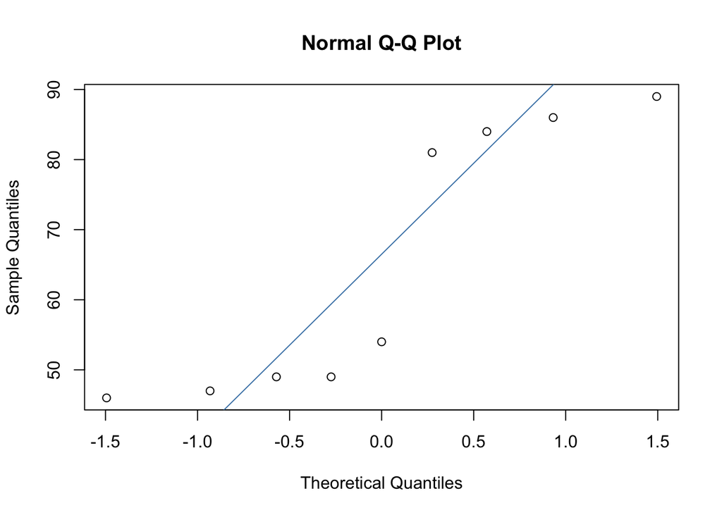

```
##
##  Shapiro-Wilk normality test
##
## data:  sleep_data$six_hours
## W = 0.7785, p-value = 0.01157
```

8 hours condition:

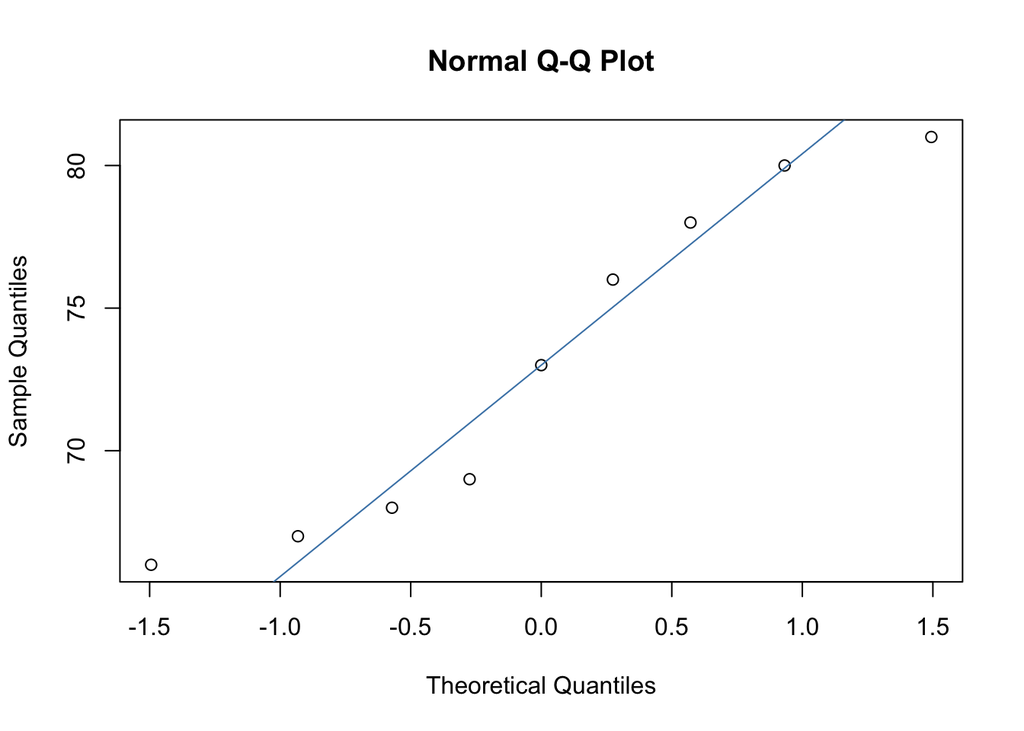

```
##
##  Shapiro-Wilk normality test
##
## data:  sleep_data$eight_hours
## W = 0.90246, p-value = 0.2666
```

10 hours condition:

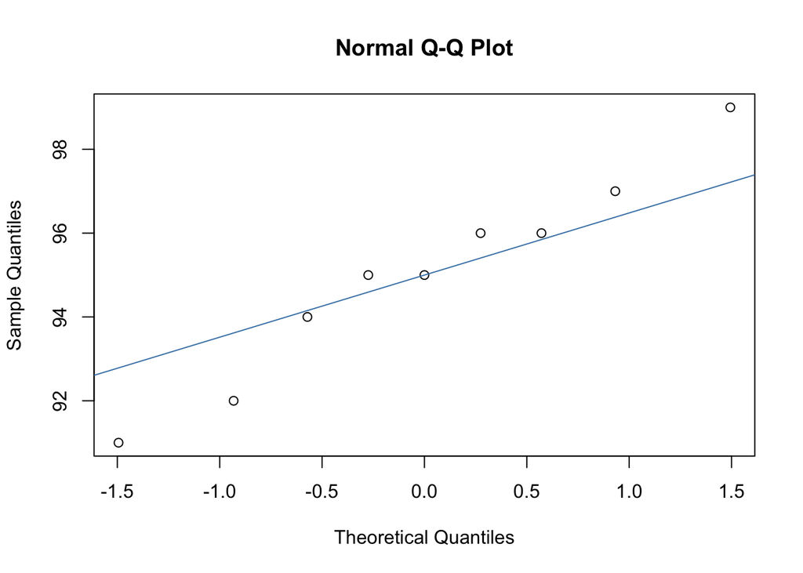

```
##
##  Shapiro-Wilk normality test
##
## data:  sleep_data$ten_hours
## W = 0.96963, p-value = 0.8915
```

**Is the assumption violated?**

Data in the 6 hour condition appears to violate the assumption of normality.

##### Interpret the descriptive statistics and the model output

```
##
##  Friedman rank sum test
##
## data:  as.matrix(sleep_data_reduced)
## Friedman chi-squared = 13.556, df = 2, p-value = 0.001139
```

```
##
##  Pairwise comparisons using Conover's all-pairs test for a two-way balanced complete block design
```

```
## data: y, groups and blocks
```

```
##           eight_hours six_hours
## six_hours 0.817       -
## ten_hours 0.015       0.014
```

```
##
## P value adjustment method: holm
```

```
##   med_six_hours med_eight_hours med_ten_hours min_six_hours min_eight_hours
## 1            54              73            95            46              66
##   min_ten_hours max_six_hours max_eight_hours max_ten_hours
## 1            91            89              81            99
```

**What can we conclude? Report in APA format.**

A Friedman’s ANOVA revealed a significantly effect of sleep hours on the attention score, $x^{2}_{F}$(2) = 13.56, *p* = .001. Post-hoc comparisons were then conducting using the Conover test, with p-values corrected using Bonferroni-Holm. A significant difference emerged between the 6 hour (median = 54; range = 46-89) and the 10 hour conditions (median = 95; range = 91-99; *p* =.014), with participants performing better in the 10 hour condition. There was also a significant difference between the 8 hour (median = 73; range = 66-81) and the 10 hour conditions (*p* = .015). No significant difference emerged between the 6 hour and 8 hour conditions (*p* = .817).